# Understanding the relationship between Income group and Gross Domestic Product.

Using World Bank Education Stats to Gross Domestic Product data

Gino Varghese

October 25, 2016

## Introduction

#### For this analysis two different data sets were used:

- First set of data contains Gross Domestic Product which is comprised of 2012 GDP values of 190 countries throughout the world. More recent data is hosted on Worldbank.org.
  - http://data.worldbank.org/data-catalog/GDP-ranking-table
- Second set contains World Bank Education Stats data.
  - http://data.worldbank.org/data-catalog/ed-stats

Our goal is to make some educated assumptions by combining both data sets to see if there is any relationship between a country’s income growth and its GDP. A country’s income growth was assessed using variables such as access to education, its progression and completion, access to teachers, family expenditure, literacy, population etc(Provided by World Bank Education stats).

#### The following was done before starting the analysis:

- setting of working directory
- installation and loading of necessary packages
- R version

```r
knitr::opts_chunk$set(echo = TRUE)
knitr::opts_knit$set(root.dir = "~/git/MSDS6306/CaseStudy01/Analysis/Data")
require(knitr)
require(dplyr)
require(plyr)
require(ggplot2)
require(downloader)
require(countrycode)
```

#### The analysis was started by downloading the following data sets:

- **Gross Domestic Product download**
  - This process downloads Gross Domestic Product data sets and renames it as “GDPbyCountry.csv”
  - Downloaded files are listed below in Data directory

```r
source("downloadGDP.R", echo = TRUE)
```

```
##
## > gdpurl <- "https://d396qusza40orc.cloudfront.net/getdata%2Fdata%2FGDP.csv"
##
## > download.file(gdpurl, destfile = "GDPbyCountry.csv",
## +     quiet = TRUE)
```

```r
list.files()
```

```
## [1] "Cleanup_EDU.R"    "Cleanup_GDP.R"    "downloadEDU.R"
## [4] "downloadGDP.R"    "GDPbyCountry.csv" "removeObjects.R"
```

- **Education data download**
  - This process downloads Education data set and renames it as “EDUbyCountry.csv”
  - Downloaded files are listed below in Data directory

```r
source("downloadEDU.R", echo = TRUE)
```

```
##
## > eduurl <- "https://d396qusza40orc.cloudfront.net/getdata%2Fdata%2FEDSTATS_Country.csv"
##
## > download.file(eduurl, destfile = "EDUbyCountry.csv",
## +     quiet = TRUE)
```

```r
list.files()
```

```
## [1] "Cleanup_EDU.R"    "Cleanup_GDP.R"    "downloadEDU.R"
## [4] "downloadGDP.R"    "EDUbyCountry.csv" "GDPbyCountry.csv"
## [7] "removeObjects.R"
```

##### Once the data was dowloaded to the project’s “Data” directory, it became ready to be imported into the R as a data frame. Once imported the data frame was observed for internal structure details and the beginning and ending of rows, to determine what actions should be taken when tidying the data.

- **Gross Domestic Product was loaded into R**
  - The csv file was loaded into **Rawgdp** data frame
    - The data frame was reviewed by using R commands such as: head, tail and str
  - The **Rawgdp** was then loaded into **GDP** data frame to begin the tidying process
  - **Tidying process**
    - The **GDP** data frame was modified as follows:
      - V[n] column headers were removed
      - Unwanted space between column header and data was removed
      - Empty columns with no data were removed
      - Column names were renamed to lower case
      - “us dollars)” column name is renamed to us.dollars
      - ISO3.CountryCode were generated for each row and stored in iso3.countrycode
        - using countrycode package
      - “Kosovo”, “Channel Islands” and “Sodom and Principe” iso3 country codes were added to the data set
      - The us.dollars column was converted into numeric, removing “,” from the dollars and “NA” rows are converted to “0”
      - Rows that are not related to any countries were moved to another data frame **GDPNoCountryCode**
        - These data sets were also removed from **GDP** data frame
      - The final rows for each data frame are as follows:
        - Raw GDP file : 331 rows
        - GDP data with NA : 112 rows
        - Tidy GDP data : 214 rows
  - Tidy data was then written to **“GDP_Final.csv”** file to facilitate analysis.

```r
source("Cleanup_GDP.R", echo = TRUE)
```

```
##
## > RAWgdp <- read.csv("GDPbyCountry.csv", header = FALSE,
## +     stringsAsFactors = FALSE)
##
## > str(RAWgdp)
## 'data.frame':    331 obs. of  10 variables:
##  $ V1 : chr  "" "" "" "" ...
##  $ V2 : chr  "Gross domestic product 2012" "" "" "Ranking" ...
##  $ V3 : logi  NA NA NA NA NA NA ...
##  $ V4 : chr  "" "" "" "Economy" ...
##  $ V5 : chr  "" "" "(millions of" "US dollars)" ...
##  $ V6 : chr  "" "" "" "" ...
##  $ V7 : logi  NA NA NA NA NA NA ...
##  $ V8 : logi  NA NA NA NA NA NA ...
##  $ V9 : logi  NA NA NA NA NA NA ...
##  $ V10: logi  NA NA NA NA NA NA ...
##
## > head(RAWgdp)
##    V1                          V2 V3            V4           V5 V6 V7 V8
## 1     Gross domestic product 2012 NA                               NA NA
## 2                                 NA                               NA NA
## 3                                 NA               (millions of    NA NA
## 4                         Ranking NA       Economy  US dollars)    NA NA
## 5                                 NA                               NA NA
## 6 USA                           1 NA United States  16,244,600     NA NA
##   V9 V10
## 1 NA  NA
## 2 NA  NA
## 3 NA  NA
## 4 NA  NA
## 5 NA  NA
## 6 NA  NA
##
## > tail(RAWgdp)
##     V1 V2 V3 V4 V5 V6 V7 V8 V9 V10
## 326       NA          NA NA NA  NA
## 327       NA          NA NA NA  NA
## 328       NA          NA NA NA  NA
## 329       NA          NA NA NA  NA
## 330       NA          NA NA NA  NA
```

[output cut: 55 more lines]

```
##
## > GDP$us.dollars[which(is.na(GDP$us.dollars) == TRUE)] <- 0
##
## > dim(RAWgdp)
## [1] 331  10
##
## > dim(GDP)
## [1] 214   6
##
## > dim(GDPNoCountryCode)
## [1] 112  11
##
## > write.csv(GDP, "GDP_Final.csv")
##
## > write.csv(GDPNoCountryCode, "GDPNoCountryCode.csv")
```

```r
source("Cleanup_EDU.R", echo = TRUE)
```

```
##
## > RAWedu <- read.csv("EDUbyCountry.csv", header = FALSE,
## +     stringsAsFactors = FALSE)
##
## > str(RAWedu)
## 'data.frame':    235 obs. of  31 variables:
##  $ V1 : chr  "CountryCode" "ABW" "ADO" "AFG" ...
##  $ V2 : chr  "Long Name" "Aruba" "Principality of Andorra" "Islamic State of Afghanistan" ...
##  $ V3 : chr  "Income Group" "High income: nonOECD" "High income: nonOECD" "Low income" ...
##  $ V4 : chr  "Region" "Latin America & Caribbean" "Europe & Central Asia" "South Asia" ...
##  $ V5 : chr  "Lending category" "" "" "IDA" ...
##  $ V6 : chr  "Other groups" "" "" "HIPC" ...
##  $ V7 : chr  "Currency Unit" "Aruban florin" "Euro" "Afghan afghani" ...
##  $ V8 : chr  "Latest population census" "2000" "Register based" "1979" ...
##  $ V9 : chr  "Latest household survey" "" "" "MICS, 2003" ...
##  $ V10: chr  "Special Notes" "" "" "Fiscal year end: March 20; reporting period for national accounts data: FY." ...
##  $ V11: chr  "National accounts base year" "1995" "" "2002/2003" ...
##  $ V12: chr  "National accounts reference year" "" "" "" ...
##  $ V13: chr  "System of National Accounts" "" "" "" ...
##  $ V14: chr  "SNA price valuation" "" "" "VAB" ...
##  $ V15: chr  "Alternative conversion factor" "" "" "" ...
##  $ V16: chr  "PPP survey year" "" "" "" ...
##  $ V17: chr  "Balance of Payments Manual in use" "" "" "" ...
##  $ V18: chr  "External debt Reporting status" "" "" "Actual" ...
##  $ V19: chr  "System of trade" "Special" "General" "General" ...
##  $ V20: chr  "Government Accounting concept" "" "" "Consolidated" ...
##  $ V21: chr  "IMF data dissemination standard" "" "" "GDDS" ...
##  $ V22: chr  "Source of most recent Income and expenditure data" "" "" "" ...
##  $ V23: chr  "Vital registration complete" "" "Yes" "" ...
##  $ V24: chr  "Latest agricultural census" "" "" "" ...
##  $ V25: chr  "Latest industrial data" "" "" "" ...
##  $ V26: chr  "Latest trade data" "2008" "2006" "2008" ...
##  $ V27: chr  "Latest water withdrawal data" "" "" "2000" ...
##  $ V28: chr  "2-alpha code" "AW" "AD" "AF" ...
##  $ V29: chr  "WB-2 code" "AW" "AD" "AF" ...
##  $ V30: chr  "Table Name" "Aruba" "Andorra" "Afghanistan" ...
##  $ V31: chr  "Short Name" "Aruba" "Andorra" "Afghanistan" ...
##
## > head(RAWedu)
##            V1                           V2                   V3
```

[output cut: 235 more lines]

```
##
## > EDU <- EDU[is.na(EDU$iso3.countrycode) == FALSE, ]
##
## > dim(RAWedu)
## [1] 235  31
##
## > dim(EDU)
## [1] 211  32
##
## > dim(EduNoCountryCode)
## [1] 23 32
##
## > write.csv(EDU, "EDU_Final.csv")
##
## > write.csv(EduNoCountryCode, "EDUNoCountryCode.csv")
```

- **Clearing existing objects**

```r
source("removeObjects.R", echo = TRUE)
```

```
##
## > remove(list = ls())
```

- **Loading tidy data for analysis**

```r
#Load cleaned up csv file for GDP

#setwd("~/git/MSDS6306/CaseStudy01/Analysis")
gdppath <- "GDP_Final.csv"
edupath <- "EDU_Final.csv"

#load and
GDP <- read.csv(gdppath,header=TRUE)
names(GDP)[names(GDP)=="X"] <- "ID"
str(GDP)
```

```
## 'data.frame':    214 obs. of  7 variables:
##  $ ID              : int  6 7 8 9 10 11 12 13 14 15 ...
##  $ countrycode     : Factor w/ 214 levels "ABW","ADO","AFG",..: 201 37 96 49 63 67 27 162 93 87 ...
##  $ ranking         : int  1 2 3 4 5 6 7 8 9 10 ...
##  $ economy         : Factor w/ 214 levels "Afghanistan",..: 204 41 95 71 66 203 27 157 93 86 ...
##  $ us.dollars      : int  16244600 8227103 5959718 3428131 2612878 2471784 2252664 2014775 2014670 1841710 ...
##  $ Comments        : Factor w/ 7 levels "","Covers mainland Tanzania only",..: 1 1 1 1 1 1 1 1 1 1 ...
##  $ iso3.countrycode: Factor w/ 214 levels "ABW","AFG","AGO",..: 203 37 98 50 65 69 27 165 95 89 ...
```

```r
EDU <- read.csv(edupath,header=TRUE)
names(EDU)[names(EDU)=="X"] <- "ID"
str(EDU)
```

```
## 'data.frame':    211 obs. of  33 variables:
##  $ ID                                               : int  2 3 4 5 6 7 8 9 10 11 ...
##  $ countrycode                                      : Factor w/ 211 levels "ABW","ADO","AFG",..: 1 2 3 4 5 6 7 8 9 10 ...
##  $ long.name                                        : Factor w/ 211 levels "American Samoa",..: 5 85 48 80 90 206 4 91 1 2 ...
##  $ income.group                                     : Factor w/ 6 levels "","High income: nonOECD",..: 2 2 5 4 6 2 6 4 6 6 ...
##  $ region                                           : Factor w/ 8 levels "","East Asia & Pacific",..: 4 3 7 8 3 5 4 3 2 4 ...
##  $ lending.category                                 : Factor w/ 4 levels "","Blend","IBRD",..: 1 1 4 4 3 1 3 2 1 3 ...
##  $ other.groups                                     : Factor w/ 3 levels "","Euro area",..: 1 1 3 1 1 1 1 1 1 1 ...
##  $ currency.unit                                    : Factor w/ 155 levels "","Afghan afghani",..: 8 49 2 5 3 144 6 7 148 44 ...
##  $ latest.population.census                         : Factor w/ 28 levels "","1970","1979",..: 17 28 3 2 18 22 18 18 17 18 ...
##  $ latest.household.survey                          : Factor w/ 56 levels "","CPS (monthly)",..: 1 1 35 34 37 1 1 14 1 1 ...
##  $ special.notes                                    : Factor w/ 48 levels "","A simple multiplier is used to convert the national currencies of EMU members to euros. The following irrevocable euro conversi"| __truncated__,..: 1 1 22 1 1 1 1 1 1 43 ...
##  $ national.accounts.base.year                      : Factor w/ 43 levels "","1954","1973",..: 24 1 37 27 1 24 21 1 1 17 ...
##  $ national.accounts.reference.year                 : int  NA NA NA NA 1996 NA NA 1996 NA NA ...
##  $ system.of.national.accounts                      : int  NA NA NA NA 1993 NA 1993 1993 NA NA ...
```

[output cut: 19 more lines]

#### Merging GDP and EDU data

The original data was cleaned and only the columns of interest were set aside for merging. The two data sets were merged together by *iso3.countrycode*.

#### Reduction to columns of interest

- iso3.countrycode
- “economy”
- “ranking”
- “income group”
- “us.dollars”

```r
names(MergeGDPInc)[names(MergeGDPInc)=="iso3.countrycode"] <- "country.code"
names(MergeGDPInc)[names(MergeGDPInc)=="economy"] <- "country.name"
names(MergeGDPInc)[names(MergeGDPInc)=="ranking"] <- "gdp.ranking"
names(MergeGDPInc)[names(MergeGDPInc)=="income group"] <- "income.group"
names(MergeGDPInc)[names(MergeGDPInc)=="us.dollars"] <- "gdp.usd"

MergeGDPInc <- subset(MergeGDPInc,select = c("country.code","country.name","gdp.ranking","income.group","gdp.usd"))

str(MergeGDPInc)
```

```
## 'data.frame':    215 obs. of  5 variables:
##  $ country.code: Factor w/ 214 levels "ABW","AFG","AGO",..: 1 2 3 4 5 6 7 8 9 10 ...
##  $ country.name: Factor w/ 214 levels "Afghanistan",..: 10 1 6 2 5 202 8 9 4 7 ...
##  $ gdp.ranking : int  161 105 60 125 NA 32 26 133 NA 172 ...
##  $ income.group: Factor w/ 6 levels "","High income: nonOECD",..: 2 5 4 6 2 2 6 4 6 6 ...
##  $ gdp.usd     : int  2584 20497 114147 12648 0 348595 475502 9951 0 1134 ...
```

### Results:

#### **Question 1:** Match the data based on the country shortcode. How many of the IDs match?

```r
## how many of the IDs match?
nrow(MergeGDPInc)
```

```
## [1] 215
```

```r
## how many of the rows contain NAs?
sum(!complete.cases(MergeGDPInc))
```

```
## [1] 26
```

```r
## Remove rows with missing data
MergeGDPInc01 <- MergeGDPInc[complete.cases(MergeGDPInc),]
nrow(MergeGDPInc01)
```

```
## [1] 189
```

```r
str(MergeGDPInc01)
```

```
## 'data.frame':    189 obs. of  5 variables:
##  $ country.code: Factor w/ 214 levels "ABW","AFG","AGO",..: 1 2 3 4 6 7 8 10 11 12 ...
##  $ country.name: Factor w/ 214 levels "Afghanistan",..: 10 1 6 2 202 8 9 7 11 12 ...
##  $ gdp.ranking : int  161 105 60 125 32 26 133 172 12 27 ...
##  $ income.group: Factor w/ 6 levels "","High income: nonOECD",..: 2 5 4 6 2 6 4 6 3 3 ...
##  $ gdp.usd     : int  2584 20497 114147 12648 348595 475502 9951 1134 1532408 394708 ...
```

##### **There are 215 matching IDs. Once all 26 NAs were removed, there remains 189 matching country code IDs.**

#### **Question 2:** Sort the data frame in ascending order by GDP (so United States is last). What is the 13th country in the resulting data frame?

```r
MergeGDPInc01 <- MergeGDPInc01[order(MergeGDPInc01$gdp.usd, decreasing = FALSE),] # Sort the data by GDP
MergeGDPInc01$country.name[13]
```

```
## [1] St. Kitts and Nevis
## 214 Levels: Afghanistan Albania Algeria American Samoa Andorra ... Zimbabwe
```

##### **St. Kitts and Nevis is the 13th country in the data frame**

#### **Question 3:** What are the average GDP rankings for the “High income: OECD” and “High income: nonOECD” groups?

```r
mean(subset(MergeGDPInc01, income.group == "High income: OECD")$gdp.ranking)    # Mean High income: OECD rank
```

```
## [1] 32.96667
```

```r
mean(subset(MergeGDPInc01, income.group == "High income: nonOECD")$gdp.ranking) # Mean High income: nonOECD rank
```

```
## [1] 91.91304
```

##### **Average *High income: OECD* GDP ranking is 32.96667.**

##### **Average *High income: nonOECD* GDP ranking is 91.91304.**

#### **Question 4:** Plot the GDP for all of the countries. Use ggplot2 to color your plot by Income.Group?

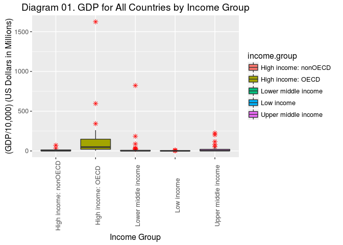

```r
 ggplot(data = MergeGDPInc01, aes(x=income.group, y=(gdp.usd/10000), fill=income.group)) +
  geom_boxplot(outlier.colour = "red", outlier.shape = 8, outlier.size = 2) +
  ggtitle("Diagram 01. GDP for All Countries by Income Group") +
  labs(x="Income Group", y="(GDP/10,000) (US Dollars in Millions)") + theme(text = element_text(size=12),
        axis.text.x = element_text(angle=90, vjust=1))
```

##### **The first boxplot visualization depicts all *GDP (US Dollars in million)* data by *Income Group*.**

##### **The data appears heavily skewed and large outliers in *High income: OECD* and *Lower middle income* makes it difficult to compare each distribution by *Income.Group*. It’s best to transform the data using log and then visualize the box plots**

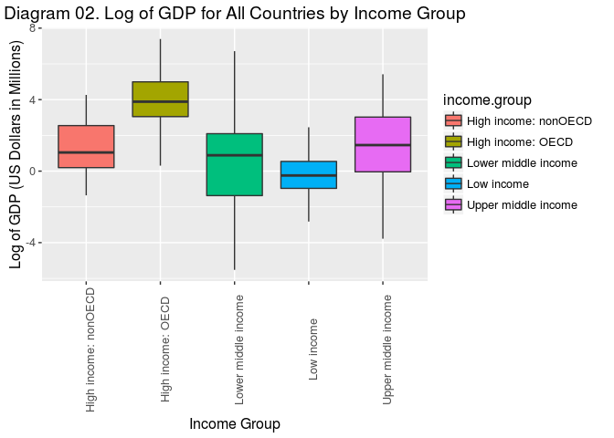

```r
 ggplot(data = MergeGDPInc01, aes(x=income.group, y=log(gdp.usd/10000), fill=income.group)) +
  geom_boxplot(outlier.colour = "red", outlier.shape = 8, outlier.size = 2) +
  ggtitle("Diagram 02. Log of GDP for All Countries by Income Group") +
  labs(x="Income Group", y="Log of GDP (US Dollars in Millions)") + theme(text = element_text(size=12),
        axis.text.x = element_text(angle=90, vjust=1))
```

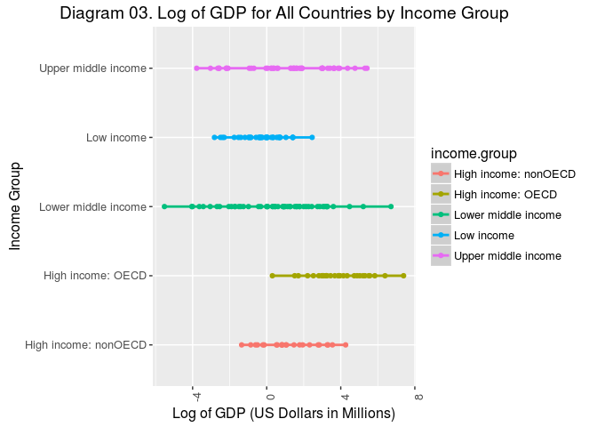

```r
 ggplot(data = MergeGDPInc01, aes(x=log(gdp.usd/10000), y=income.group, group=income.group)) +
    stat_smooth(aes(colour=income.group))+
  geom_point(aes(colour = income.group)) +
  #geom_boxplot(outlier.colour = "red", outlier.shape = 8, outlier.size = 2) +
  ggtitle("Diagram 03. Log of GDP for All Countries by Income Group") +
  labs(x="Log of GDP (US Dollars in Millions)", y="Income Group") + theme(text = element_text(size=12),
       axis.text.x = element_text(angle=90, vjust=1))
```

##### As soon as the data was log transformed (shown in diagram 02 & 03), it was evident that most of the *High income: OECD* group data exceeded the remaining groups’ data in terms of GDP. It also appears that the *High income: nonOECD* group is nearly identical to the *Upper middle income’s*.

#### **Question 5:** Cut the GDP ranking into 5 separate quantile groups. Make a table versus Income.Group. How many countries are lower middle income but among the 38 nations with the highest GDP?

##### **ntile** function is used to split the GDP rankings into 5 separate quantile groups, this function is from the *dplyr* package.

```r
MergeQuantile <- MergeGDPInc01
MergeQuantile$gdp.quantile <- ntile(MergeQuantile$gdp.ranking, 5) # Add 5 quantiles by Country.Rank to new GDP.Quantile column

## Generate table by Income.Group output
table(MergeQuantile$income.group, MergeQuantile$gdp.quantile, dnn = c("Income.Group","GDP.Quantile"))
```

```
##                       GDP.Quantile
## Income.Group            1  2  3  4  5
##                         0  0  0  0  0
##   High income: nonOECD  4  5  8  5  1
##   High income: OECD    18 10  1  1  0
##   Lower middle income   5 13 12  8 16
##   Low income            0  1  9 16 11
##   Upper middle income  11  9  8  8  9
```

```r
## Confirm number of lower middle income countries as listed in the table above
sum(MergeQuantile[(nrow(MergeQuantile)-37):nrow(MergeQuantile),]$income.group == "Lower middle income")
```

```
## [1] 5
```